# IODS course project

Mikko Patronen

## 1. Introduction to Open Data Science 2018

This course will provide a lot of very useful basic knowledge on open source data workflow.

Link to my GitHub repository:  
https://github.com/MikkoPatronen/IODS-project

## 2. Regression and model validation

### 1. The structure and dimensions of the data

```
## 'data.frame':    166 obs. of  7 variables:
##  $ gender  : Factor w/ 2 levels "F","M": 1 2 1 2 2 1 2 1 2 1 ...
##  $ age     : int  53 55 49 53 49 38 50 37 37 42 ...
##  $ attitude: int  37 31 25 35 37 38 35 29 38 21 ...
##  $ deep    : num  3.58 2.92 3.5 3.5 3.67 ...
##  $ stra    : num  3.38 2.75 3.62 3.12 3.62 ...
##  $ surf    : num  2.58 3.17 2.25 2.25 2.83 ...
##  $ points  : int  25 12 24 10 22 21 21 31 24 26 ...
```

### 2. A graphical overview and summaries of variables in the data

```
##  gender       age           attitude          deep            stra
##  F:110   Min.   :17.00   Min.   :14.00   Min.   :1.583   Min.   :1.250
##  M: 56   1st Qu.:21.00   1st Qu.:26.00   1st Qu.:3.333   1st Qu.:2.625
##          Median :22.00   Median :32.00   Median :3.667   Median :3.188
##          Mean   :25.51   Mean   :31.43   Mean   :3.680   Mean   :3.121
##          3rd Qu.:27.00   3rd Qu.:37.00   3rd Qu.:4.083   3rd Qu.:3.625
##          Max.   :55.00   Max.   :50.00   Max.   :4.917   Max.   :5.000
##       surf           points
##  Min.   :1.583   Min.   : 7.00
##  1st Qu.:2.417   1st Qu.:19.00
##  Median :2.833   Median :23.00
##  Mean   :2.787   Mean   :22.72
##  3rd Qu.:3.167   3rd Qu.:27.75
##  Max.   :4.333   Max.   :33.00
```

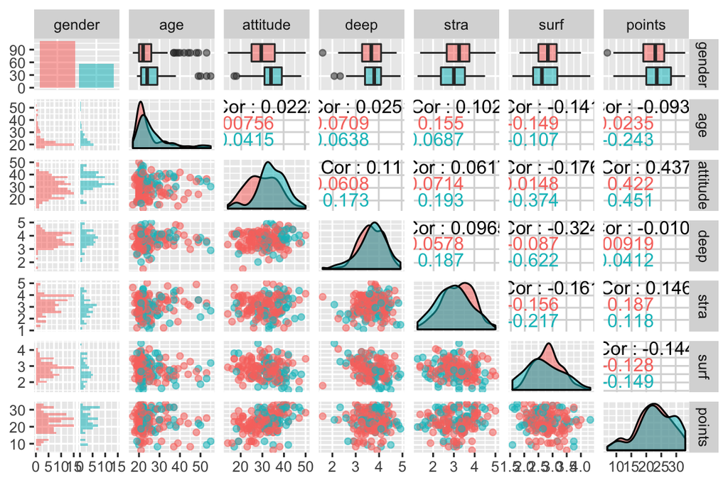

There are almost twice as many answers from females (n = 110) than males (n = 56). Their age varies between 17 and 55 years, half of the participants being at least 22 years old.

### 3. Regression model

I chose the variables “attitude”, “stra” and “surf” as explanatory variables for the target variable “points”. Here is the summary for the fitted model:

```
##
## Call:
## lm(formula = points ~ attitude + stra + surf, data = learning2014)
##
## Residuals:
##      Min       1Q   Median       3Q      Max
## -17.1550  -3.4346   0.5156   3.6401  10.8952
##
## Coefficients:
##             Estimate Std. Error t value Pr(>|t|)
## (Intercept) 11.01711    3.68375   2.991  0.00322 **
## attitude     0.33952    0.05741   5.913 1.93e-08 ***
## stra         0.85313    0.54159   1.575  0.11716
## surf        -0.58607    0.80138  -0.731  0.46563
## ---
## Signif. codes:  0 '***' 0.001 '**' 0.01 '*' 0.05 '.' 0.1 ' ' 1
##
## Residual standard error: 5.296 on 162 degrees of freedom
## Multiple R-squared:  0.2074, Adjusted R-squared:  0.1927
## F-statistic: 14.13 on 3 and 162 DF,  p-value: 3.156e-08
```

According to the model the variables “stra” and “surf” do not have statistically significant relationship with the target (p-values 0.117 and 0.466). Since the variable “surf” has bigger p-value, let us remove that from the model and fit a new model without it. Here is the new fitted model summary:

```
##
## Call:
## lm(formula = points ~ attitude + stra, data = learning2014)
##
## Residuals:
##      Min       1Q   Median       3Q      Max
## -17.6436  -3.3113   0.5575   3.7928  10.9295
##
## Coefficients:
##             Estimate Std. Error t value Pr(>|t|)
## (Intercept)  8.97290    2.39591   3.745  0.00025 ***
## attitude     0.34658    0.05652   6.132 6.31e-09 ***
## stra         0.91365    0.53447   1.709  0.08927 .
## ---
## Signif. codes:  0 '***' 0.001 '**' 0.01 '*' 0.05 '.' 0.1 ' ' 1
##
## Residual standard error: 5.289 on 163 degrees of freedom
## Multiple R-squared:  0.2048, Adjusted R-squared:  0.1951
## F-statistic: 20.99 on 2 and 163 DF,  p-value: 7.734e-09
```

Now the model summary shows that the variable “stra” does not have statistically significant relationship with the target (p-value is 0.089), so I create a new model without it. Here is the final model summary:

```
##
## Call:
## lm(formula = points ~ attitude, data = learning2014)
##
## Residuals:
##      Min       1Q   Median       3Q      Max
## -16.9763  -3.2119   0.4339   4.1534  10.6645
##
## Coefficients:
##             Estimate Std. Error t value Pr(>|t|)
## (Intercept) 11.63715    1.83035   6.358 1.95e-09 ***
## attitude     0.35255    0.05674   6.214 4.12e-09 ***
## ---
## Signif. codes:  0 '***' 0.001 '**' 0.01 '*' 0.05 '.' 0.1 ' ' 1
##
## Residual standard error: 5.32 on 164 degrees of freedom
## Multiple R-squared:  0.1906, Adjusted R-squared:  0.1856
## F-statistic: 38.61 on 1 and 164 DF,  p-value: 4.119e-09
```

This model has an assumption that the attitude towards statistics has a linear relationship with exam points. The explanatory variable “attitude” has a statistically significant relationship with the target variable “points” (p-value almost 0).

### 4.

The model shows that the y-intercept is at 11.637 and the linear model has a positive slope of 0.353, which means that when the attitude goes up one point, the exam points rise 0.353. This seems reasonable.

Multiple R squared can be interpreted as displaying the amount of variance (in percentages) the explanatory variable(s) explain in the target variable. So in this model it could be interpreted that the attitude explains about 19 percent of the variance in exam points.

### 5.

The model has an assumption that the residuals are normally distributed. The residuals are the differences between the predicted and observed values in a given point.

## 3: Logistic regression

The data consists of two data sets retrieved from the UCI Machine Learning Repository using Student performance dataset from https://archive.ics.uci.edu/ml/datasets/Student+Performance. The data attributes include student grades, demographic, social and school related features and it was collected by using school reports and questionnaires. Two datasets are provided regarding the performance in two distinct subjects: Mathematics (mat) and Portuguese language (por). One table was students from a math course, and the other students from Portuguese course. The two datasets were combined for this analysis.

The data consists of 382 obsevations (students) and 35 variables. The 35 column names are as follows:

```
##  [1] "school"     "sex"        "age"        "address"    "famsize"
##  [6] "Pstatus"    "Medu"       "Fedu"       "Mjob"       "Fjob"
## [11] "reason"     "nursery"    "internet"   "guardian"   "traveltime"
## [16] "studytime"  "failures"   "schoolsup"  "famsup"     "paid"
## [21] "activities" "higher"     "romantic"   "famrel"     "freetime"
## [26] "goout"      "Dalc"       "Walc"       "health"     "absences"
## [31] "G1"         "G2"         "G3"         "alc_use"    "high_use"
```

Two variables are describing the student’s alcohol use. The variable “alc_use” is the average alcochol use on weekdays and weekends together. The variable “high_use” indicates if the average alcohol use is more than 2.

I chose 4 variables that I believe to have some relationship with the alcohol consumption. The variables are “sex”, “studytime”, “activities” and “romantic”. The gender (“sex”), extra-curricular activities (“activities”) and relationship status (“romantic”) are binary variables. Weekly studytime is numeric varying in 4 different categories between 1 and 10 hours. I would hypothesize that males, those who do not have extra-curricular activities, those who are not in a romantic relationship, and those with lower amounts of weekly studytime, have higher probability to high use alcohol consumption.

### *Tables and numerical evaluation of the relationships*

#### High alcohol use vs. gender

I think a barplot will describe the relationships quite well. This barplot below shows the mean of alcohol consumption according to gender. It can clearly be seen from the plot that males are the majority in larger means of alcohol consumption. This is especially clear when the mean value is 3 or higher. The summary statistic by group tells us the numbers: there are 72 males and 42 females in the high alcohol use group. This supports our hypothesis.

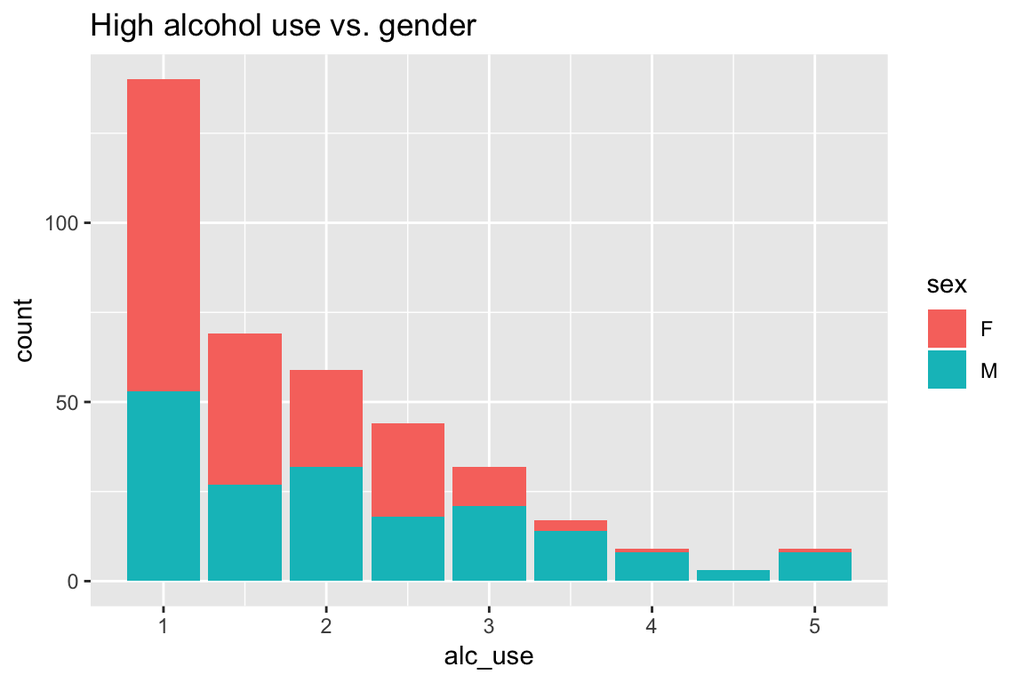

```
## # A tibble: 4 x 3
## # Groups:   sex [?]
##   sex   high_use count
##   <fct> <lgl>    <int>
## 1 F     FALSE      156
## 2 F     TRUE        42
## 3 M     FALSE      112
## 4 M     TRUE        72
```

#### High alcohol use vs. extra-curricular activities

The next barplot shows the mean of alcohol consumption according to the binary variable “activities”, which describes whether or not the individual has extra-curricular activities. This plot is not as clear as the previous one, but those who do not have extra-curricular activities are a slight majority in mean values above 2. The summary statistic by group shows that there are 59 “no’s” and 55 “yes’s” in the high alcohol use group. This supports our hypothesis, but is really small difference.

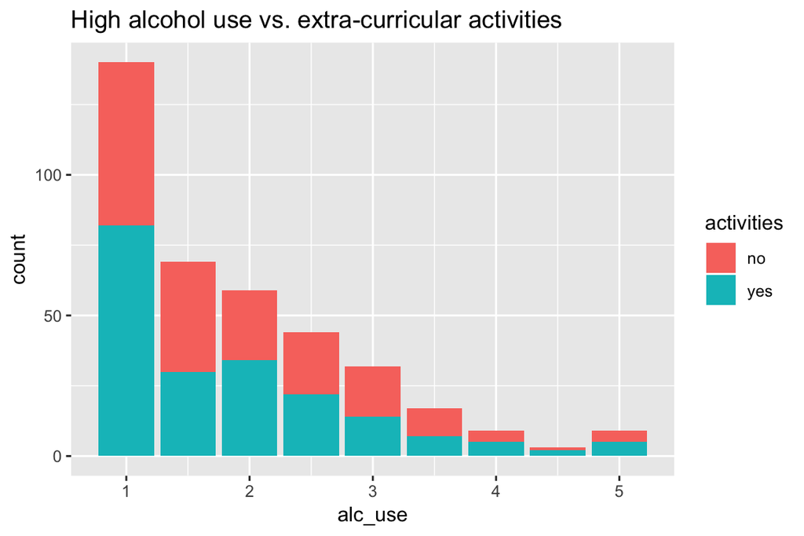

```
## # A tibble: 4 x 3
## # Groups:   activities [?]
##   activities high_use count
##   <fct>      <lgl>    <int>
## 1 no         FALSE      122
## 2 no         TRUE        59
## 3 yes        FALSE      146
## 4 yes        TRUE        55
```

#### High alcohol use vs. being in a romantic relationship

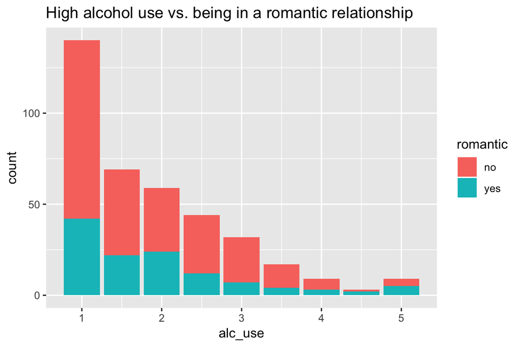

```
## # A tibble: 4 x 3
## # Groups:   romantic [?]
##   romantic high_use count
##   <fct>    <lgl>    <int>
## 1 no       FALSE      180
## 2 no       TRUE        81
## 3 yes      FALSE       88
## 4 yes      TRUE        33
```

#### High alcohol use vs. studytime

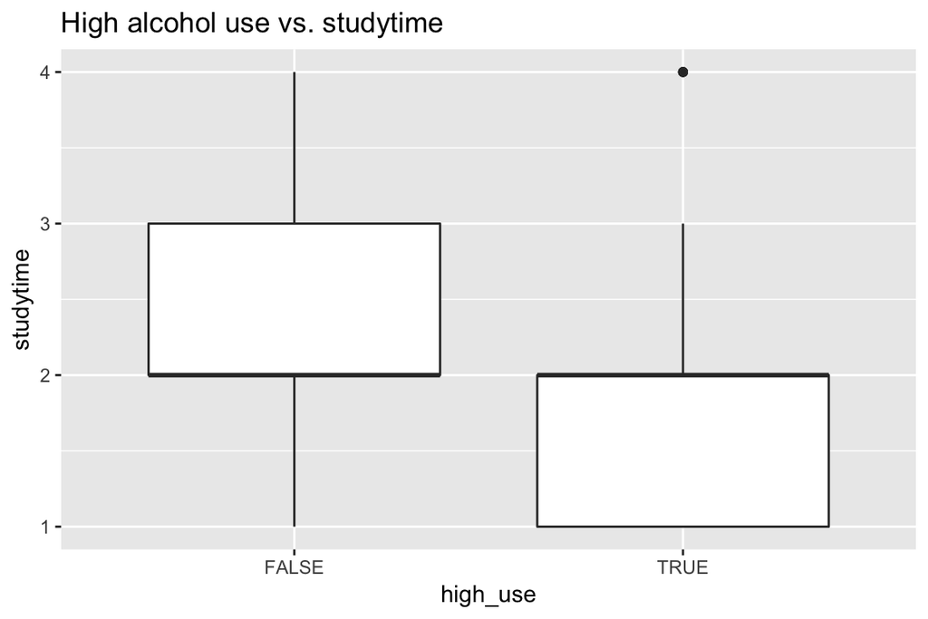

```
## # A tibble: 8 x 3
## # Groups:   studytime [?]
##   studytime high_use count
##       <int> <lgl>    <int>
## 1         1 FALSE       58
## 2         1 TRUE        42
## 3         2 FALSE      135
## 4         2 TRUE        60
## 5         3 FALSE       52
## 6         3 TRUE         8
## 7         4 FALSE       23
## 8         4 TRUE         4
```

### Logistic regression

Next I will conduct a logistic regression analysis to study the relationships between the independent variables (“sex”, “studytime”, “activities” and “romantic”) and the dependent variable (high_use: the mean alcohol use > 2). Here is the summary of the analysis:

```
##
## Call:
## glm(formula = high_use ~ sex + romantic + activities + studytime,
##     family = "binomial", data = alc2)
##
## Deviance Residuals:
##     Min       1Q   Median       3Q      Max
## -1.2083  -0.8872  -0.6806   1.1819   2.0591
##
## Coefficients:
##               Estimate Std. Error z value Pr(>|z|)
## (Intercept)   -0.17051    0.38376  -0.444  0.65681
## sexM           0.69839    0.24552   2.845  0.00445 **
## romanticyes   -0.08315    0.25272  -0.329  0.74213
## activitiesyes -0.26321    0.23571  -1.117  0.26414
## studytime     -0.45540    0.15754  -2.891  0.00384 **
## ---
## Signif. codes:  0 '***' 0.001 '**' 0.01 '*' 0.05 '.' 0.1 ' ' 1
##
## (Dispersion parameter for binomial family taken to be 1)
##
##     Null deviance: 465.68  on 381  degrees of freedom
## Residual deviance: 439.32  on 377  degrees of freedom
## AIC: 449.32
##
## Number of Fisher Scoring iterations: 4
```

```
##   (Intercept)          sexM   romanticyes activitiesyes     studytime
##    -0.1705116     0.6983944    -0.0831546    -0.2632122    -0.4553951
```

```
##
## Call:
## glm(formula = high_use ~ sex + studytime, family = "binomial",
##     data = alc2)
##
## Deviance Residuals:
##     Min       1Q   Median       3Q      Max
## -1.1429  -0.8820  -0.7177   1.2123   2.1421
##
## Coefficients:
##             Estimate Std. Error z value Pr(>|z|)
## (Intercept)  -0.2621     0.3726  -0.704  0.48169
## sexM          0.6618     0.2413   2.743  0.00610 **
## studytime    -0.4815     0.1566  -3.075  0.00211 **
## ---
## Signif. codes:  0 '***' 0.001 '**' 0.01 '*' 0.05 '.' 0.1 ' ' 1
##
## (Dispersion parameter for binomial family taken to be 1)
##
##     Null deviance: 465.68  on 381  degrees of freedom
## Residual deviance: 440.71  on 379  degrees of freedom
## AIC: 446.71
##
## Number of Fisher Scoring iterations: 4
```

```
## (Intercept)        sexM   studytime
##  -0.2621283   0.6618371  -0.4814874
```

```
##                    OR     2.5 %    97.5 %
## (Intercept) 0.7694123 0.3707640 1.6029554
## sexM        1.9383500 1.2105015 3.1228545
## studytime   0.6178637 0.4502538 0.8331592
```

This model also gives statistically significant estimates for gender and studytime. Odds ratios can be interpreted so that males are 1.94 (95% confidence interval 1.21 - 3.12) times more likely to be high users of alcohol and also that studytime increase is associated with decreasing mean of alcohol consumption (OR 0.62, 95% confidence interval 0.45 - 0.83). These both interpretations support the original hypothesis: males are more likely to be high users of alcohol and low amount of studytime is associated with higher amounts of alcohol use.